# Software for analysing the Power to Detect Change

LAS Scott-Hayward and ML Mackenzie

2017-03-13

#### This vignette constitutes work carried out at the Centre for Research into Ecological and Environmental Modelling (CREEM) at the University of St. Andrews.

**Please reference this document as:** Scott-Hayward, L.A.S. and Mackenzie, M.L. (2017). Vignette for the MRSeaPower Package v0.99: Software for analysing the Power to Detect Change. Centre for Research into Ecological and Environmental Modelling, University of St Andrews.

# Initial Setup

1. Load data (when loaded the dataframe is called `nysted`)

```r
data("nystedA_slim")
```

2. Load associated data:
- study area boundary (polygon)
- windfarm location boundary (polygon)
- prediction grid (regular coordinate grid with covariates)

The names in the dataframe for these are the same as those given when loading.

```r
data("nysted.studybnd")
data("nysted.bndwf")
data("nysted.predgrid")
```

3. Add two new columns to the dataset.
   - For the modelling process later, it will be useful to define a potential blocking structure, here we use unique transect label.
   - We also create an identifier defining the fold of data for each data point for use in cross-validation calculation later. By defining the blocking structure, if any correlation is found to be present in model residuals, the nature of it will be preserved in each fold.

```r
nysted$panelid<-as.numeric(nysted$unique.transect.label)
nysted$foldid<-getCVids(nysted, 10, 'panelid')
```

4. Make a plot of the data and windfarm boundary to confirm all looks ok.

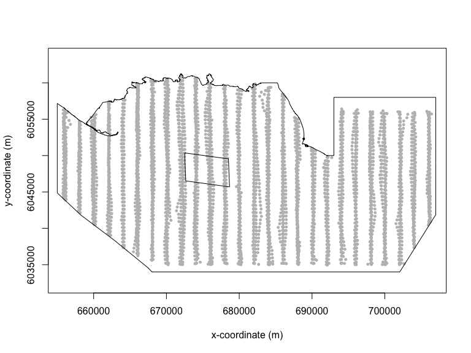

```r
require(splancs)
plot(nysted$x.pos, nysted$y.pos, pch=20, cex=0.8, col='grey', xlab='x-coordinate (m)',
     ylab='y-coordinate (m)', asp=1)
polymap(nysted.bndwf, add=T)
polymap(nysted.studybnd, add=T)
```

# Model Fitting

Now that we have our data in order, we can begin the modelling process. This practical takes fits a very simplistic model (linear terms only) in order that you may progress to the power analysis step quickly.

1. Fit an initial model

```r
initialModel<-gamMRSea(response ~ 1 + as.factor(yearmonth)+depth +
                    x.pos + y.pos + offset(log(area)),  data=nysted, family=quasipoisson)
```

2. Use an ANOVA from the `MRSea` library to check that the model covariates should all be selected.

```r
anova(initialModel, test='F')
```

```
## Analysis of Deviance Table (Type II tests)
## Marginal Testing
##
## Response: response
## Error estimate based on Pearson residuals
##
##                          SS   Df       F    Pr(>F)
## as.factor(yearmonth)  19421    5  64.781 < 2.2e-16 ***
## depth                 26011    1 433.800 < 2.2e-16 ***
## x.pos                  3177    1  52.980 3.798e-13 ***
## y.pos                 14010    1 233.660 < 2.2e-16 ***
## Residuals            363537 6063
## ---
## Signif. codes:  0 '***' 0.001 '**' 0.01 '*' 0.05 '.' 0.1 ' ' 1
```

3. All covariates are significant so we continue to check if there is residual correlation based on this data/model combination using an Empirical Runs Test and an autocorrelation function (acf) plot.

This empirical test involves generating several sets of data from the fitted model (under independence), fitting the model each time and calculating the runs test statistic based on the model residuals in each case. This forms the reference distribution for the runs test statistic which we have observed in this case. If our observed test statistic is typical of that encountered under independence then this provides no evidence for any correlation, however if the observed test statistic is peculiar under independence then this provides evidence for residual correlation.

```r
bestModel<-initialModel
```

- Generate some independent data:

```r
nsim<-550
d<-as.numeric(summary(bestModel)$dispersion)
newdat<-generateNoise(nsim, fitted(bestModel), family='poisson', d=d)
```

- Loop over all simulated sets of data to harvest the empirical distribution of runs test statistics
- If you use `dots=TRUE` then a progress bar will be printed.

```r
empdistribution<-getEmpDistribution(n.sim = nsim, simData=newdat,   model = bestModel,
                                 data = nysted, plot=FALSE,   returnDist = TRUE, dots=FALSE)
```

- Find the runs test result for our model residuals and plot the acf function for comparison.

```r
runsTest(residuals(bestModel, type='pearson'), emp.distribution = empdistribution)
```

```
    Runs Test - Two sided; Empirical Distribution

data:  residuals(bestModel, type = "pearson")
Standardized Runs Statistic = -55.11, p-value < 2.2e-16
```

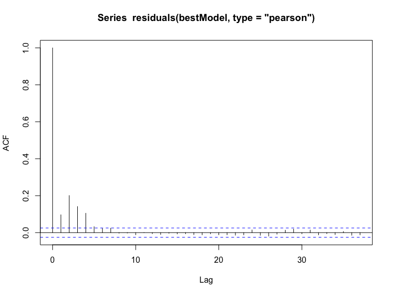

```r
acf(residuals(bestModel, type='pearson'))
```

In this case, we have evidence that the model residuals (Pearsons) are correlated ($p$ value is small). This conclusion is consistent with the acf plot.

## Data generation

1. Generate noisy correlated data.

```r
newdat<-generateNoise(nsim, fitted(bestModel), family='poisson', d=d)
corrs<-getCorrelationMat(panel = nysted$panelid, data=nysted$response, dots = FALSE)
newdat.ic<-generateIC(nysted, corrs, "panelid", newdat, nsim=nsim, dots = FALSE)
```

2. Given that we know we have correlation present, now we must add a panel structure to our model. This means that now when we produce summaries or use the anova function, the `gamMRSea` based functions will be called and the robust standard errors used for inference.

```r
bestModel<-make.gamMRSea(bestModel, panelid=nysted$panelid)
```

## Data generation diagnostics

Assess the data generation process using:

1. `plotMean`
2. `plotVariance`
3. `acf` plots
4. and `quilt.plots`
5. `plotMean`

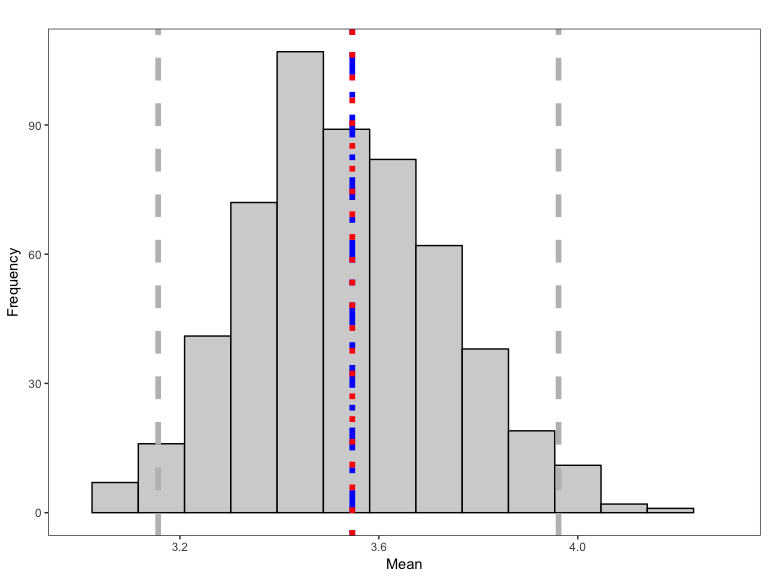

Histogram of the mean of the simulated data, with the red line representing the mean of the original data and the blue line is the mean of the fitted values from the data generation model. The grey lines represent 95% confidence intervals for the simulated mean.

```r
require(ggplot2)
plotMean(bestModel, newdat.ic)
```

- if you want to change the histogram ‘bin’ size or the confidence level of the intervals then there are options `binsize` and `quants`. The defaults for these are 15 and c(0.025,0.975).
2. `plotVariance`

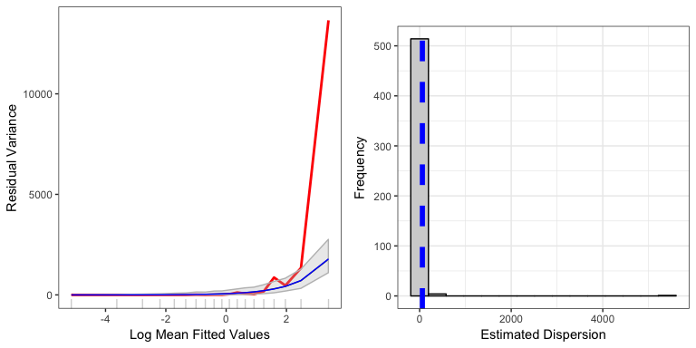

```r
plotVariance(bestModel, newdat.ic, n.sim=nsim)
```

- if you want to change the confidence level, there is a `quants` option as for the `plotMean` function.
- There is also an option to change the number of cut points - i.e. how many bins/buckets the fitted values are split into.
- You may also store some of the outputs from the model using `store.data=TRUE`.

Remember, not all models fitted to each simulated set will be appropriate. Some may exhibit extreme estimates for coefficient values.

- `badsim.id` is placed in your workspace to identify bad simulations. To prevent issues these are removed.

```r
length(badsim.id)
```

```
## [1] 31
```

```r
newdat.ic<-newdat.ic[,-badsim.id]
dim(newdat.ic)
```

```
## [1] 6072  519
```

- Re-assessing the dimensions of the newdat.ic, we see that we now have fewer than 550 generated data sets.
3. ACF plots:

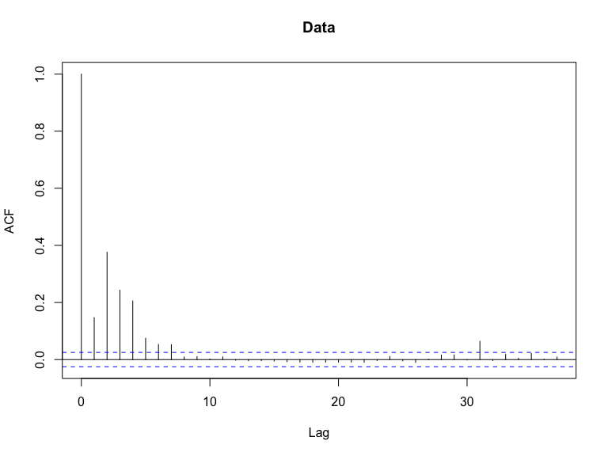

ACF plots for the response data (top left), an example of the simulated data (top right), the pearsons residuals for the data generation model (bottom left) and the residuals for a model fitted to the generated data.

```r
#par(mfrow=c(2,2))
acf(nysted$response, main='Data')
```

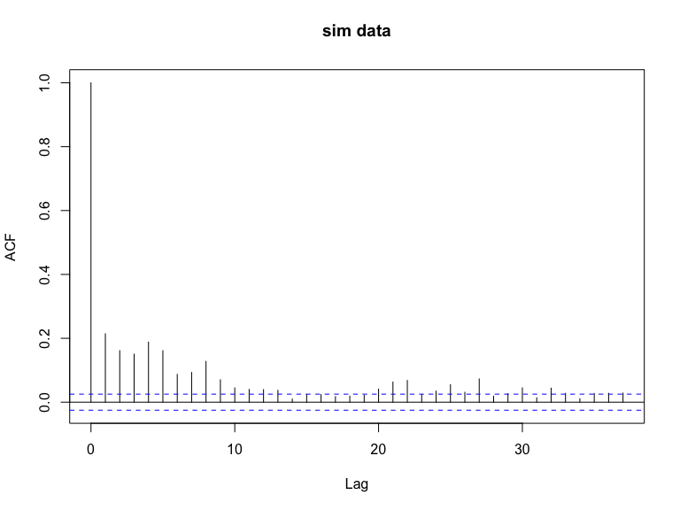

ACF plots for the response data (top left), an example of the simulated data (top right), the pearsons residuals for the data generation model (bottom left) and the residuals for a model fitted to the generated data.

```r
acf(newdat.ic[,10], main='sim data')
```

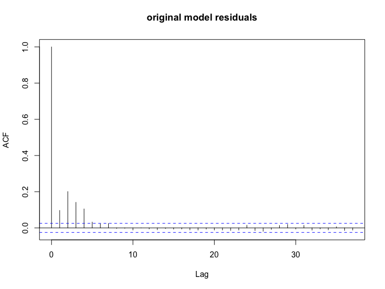

ACF plots for the response data (top left), an example of the simulated data (top right), the pearsons residuals for the data generation model (bottom left) and the residuals for a model fitted to the generated data.

```r
acf(residuals(bestModel, type='pearson'), main='original model residuals')
```

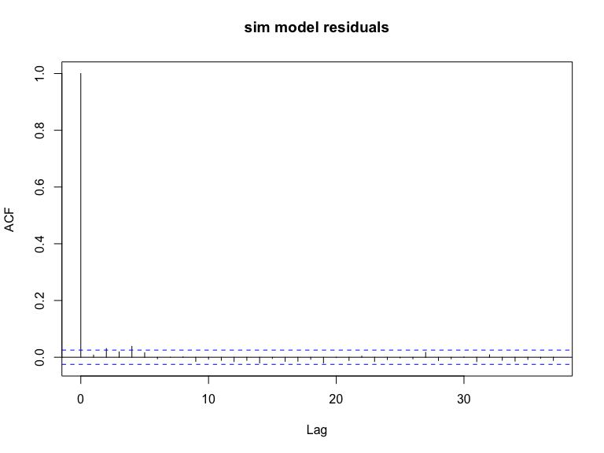

ACF plots for the response data (top left), an example of the simulated data (top right), the pearsons residuals for the data generation model (bottom left) and the residuals for a model fitted to the generated data.

```r
acf(residuals(update(bestModel, newdat.ic[,10] ~ .), type='pearson'), main='sim model residuals')
```

For interest, you can see what the ACF plots would have looked like if we had used the independent data.

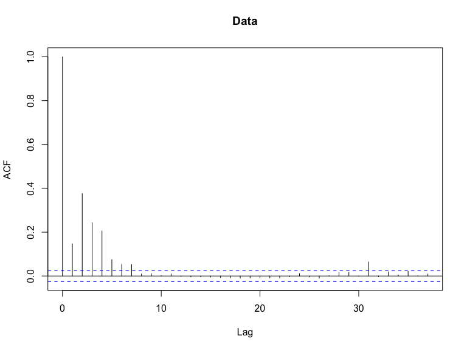

ACF plots for the response data (top left), an example of the simulated data (top right), the pearsons residuals for the data generation model (bottom left) and the residuals for a model fitted to the generated data.

```r
#par(mfrow=c(2,2))
acf(nysted$response, main='Data')
```

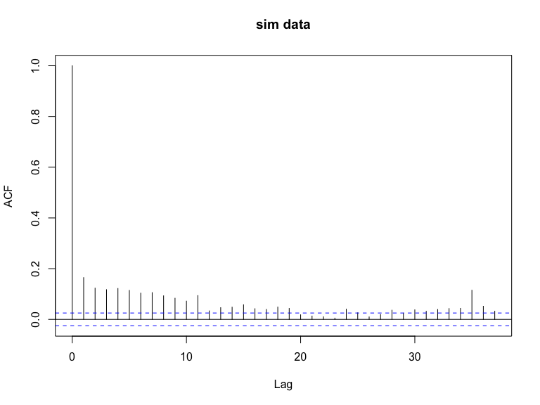

ACF plots for the response data (top left), an example of the simulated data (top right), the pearsons residuals for the data generation model (bottom left) and the residuals for a model fitted to the generated data.

```r
acf(newdat[,10], main='sim data')
```

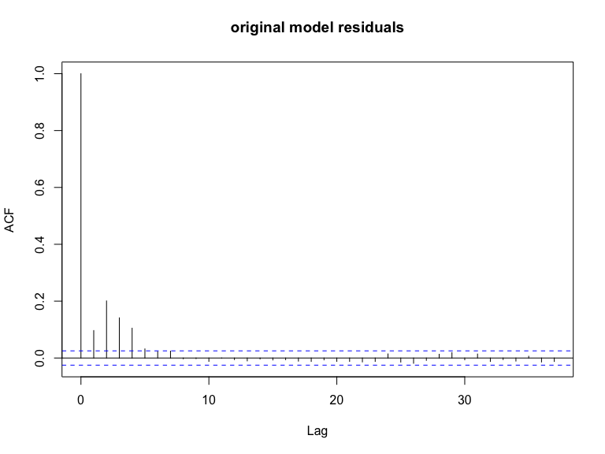

ACF plots for the response data (top left), an example of the simulated data (top right), the pearsons residuals for the data generation model (bottom left) and the residuals for a model fitted to the generated data.

```r
acf(residuals(bestModel, type='pearson'), main='original model residuals')
```

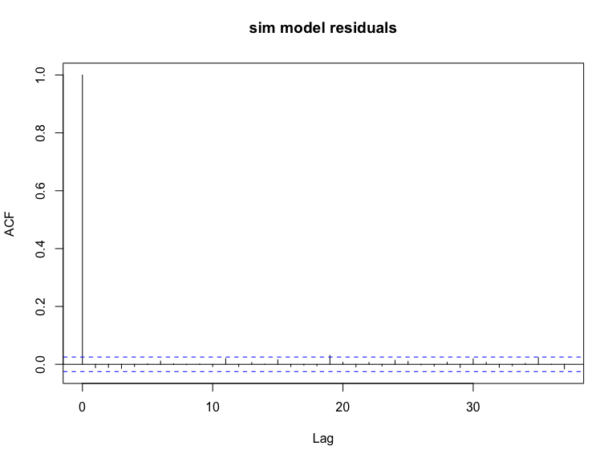

ACF plots for the response data (top left), an example of the simulated data (top right), the pearsons residuals for the data generation model (bottom left) and the residuals for a model fitted to the generated data.

```r
acf(residuals(update(bestModel, newdat[,10] ~ .), type='pearson'), main='sim model residuals')
```

4. Quilt plots to show the data spatially.

The single simulated data example shows the extent of the variability encountered across simulations but is broadly similar to the fitted values.

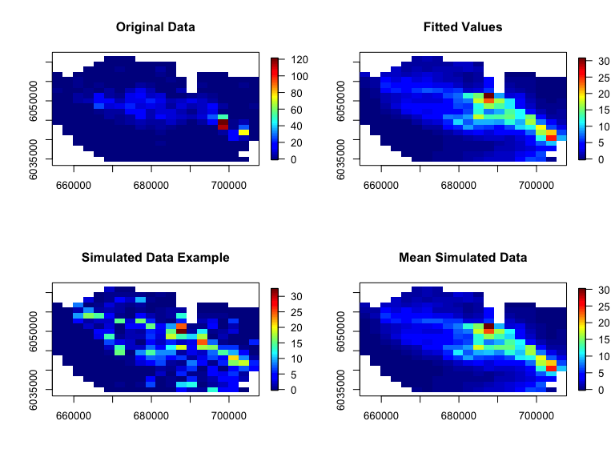

Figure showing the spatial distribution of the original data (top left), the fitted values from the model (top right), an example of the simulated data (bottom left) and the mean of all simulated data (bottom right).

```r
require(fields)
par(mfrow=c(2,2))
quilt.plot(nysted$x.pos, nysted$y.pos, nysted$response, main='Original Data',
           ncol=20, nrow=20, asp=1)
quilt.plot(nysted$x.pos, nysted$y.pos, fitted(bestModel), main='Fitted Values',
           ncol=20, nrow=20, asp=1)
quilt.plot(nysted$x.pos, nysted$y.pos, newdat.ic[,1], main='Simulated Data Example',
           ncol=20, nrow=20, asp=1)
quilt.plot(nysted$x.pos, nysted$y.pos, apply(newdat.ic, 1, mean), main='Mean Simulated Data',
           ncol=20, nrow=20, asp=1)
```

The extent of the bias in the generation process is also evidence below with no concerning patterns

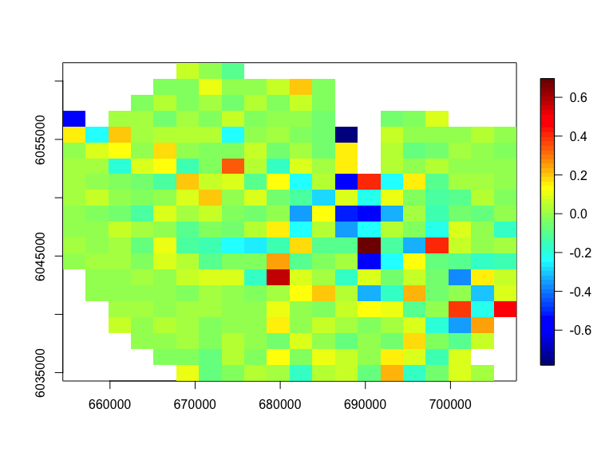

Figure showing the average simulated value minus the “true” value under the model (simulating the data) at each location.

```r
par(mfrow=c(1,1))
quilt.plot(nysted$x.pos, nysted$y.pos, apply(newdat.ic, 1, mean) - fitted(bestModel),
           ncol=20, nrow=20)
```

# Inducing a 20% site-wide decline

In order to impose change on our generated data we need to know what the post-change result is and how many simulations are required. Naturally, we also need to know what model/data combination we are using to underpin the spatially explicit power analysis.

In this case, we wish to reduce overall numbers by 20% and so the post-change situation has 80% of the abundance observed pre-change (and so `truebeta` is set to be 0.8).

We choose 500 simulations for this analysis and we use the `genChangeData` function to give us our simulated sets.

Note that we may not use all 500 sets for the power analysis but may as well generate more than we need.

## Generate data

1. Induce change in post impact data

```r
truebeta<-0.80
impdata.ny<-genChangeData(truebeta*100, model = bestModel, data = nysted,
                           panels = "panelid")
```

2. As a sense check, it is wise to summarise our generated data pre and post change to ensure our desired increase/decrease has been observed (in this case a 20% decline in average numbers). We can also check at this point that we have equal numbers of observations before and post event.

```r
require(dplyr)
t<-group_by(impdata.ny, eventphase)%>%
  summarise(sum=sum(truth), mean=mean(truth), n=n())
t
```

```
# A tibble: 2 × 4
  eventphase   sum     mean     n
       <dbl> <dbl>    <dbl> <int>
1          0 21535 3.546607  6072
2          1 17228 2.837286  6072
```

To assess the imposed change visually, it is easiest to look at the difference between the before and after surfaces. However, the survey data is not regularly spaced making the `ggplot2` plotting engine difficult to use.

- I have chosen here to make a `ggplot2` based plot but if you would rather, you could equally do this using `quilt.plot` which automatically uses the mean in each pixel.
- Here we turn the data into a raster (regular grid) and take the mean of any cells occupying the same cell on the grid.
  - Note that this is done automatically when using `quilt.plot` with nrows/ncols used to determine the grid size.
  - the default for `ggplot2` is to plot all the data in order, thus the final image shows only the last value of a particular grid cell (as opposed to the mean).
- Rasterise the before and after data:

```r
rdf1<-make.raster(ncell.y=60,
                  xyzdata=impdata.ny[impdata.ny$eventphase==0,c("x.pos", "y.pos", "truth")],
                  z.name = "Mean.count")

rdf2<-make.raster(ncell.y=60,
                  xyzdata=impdata.ny[impdata.ny$eventphase==0,c("x.pos", "y.pos", "truth")],
                  z.name="Mean.count")

rdf<-rbind(data.frame(rdf1, evph=0), data.frame(rdf2, evph=1))
```

- Find the percentage change in each grid cell (you could do this for absolute difference if you prefer)

```r
pct.change<-((rdf$Mean.count[rdf$evph==1] - rdf$Mean.count[rdf$evph==0])/
               rdf$Mean.count[rdf$evph==0])*100
```

- Plot the data

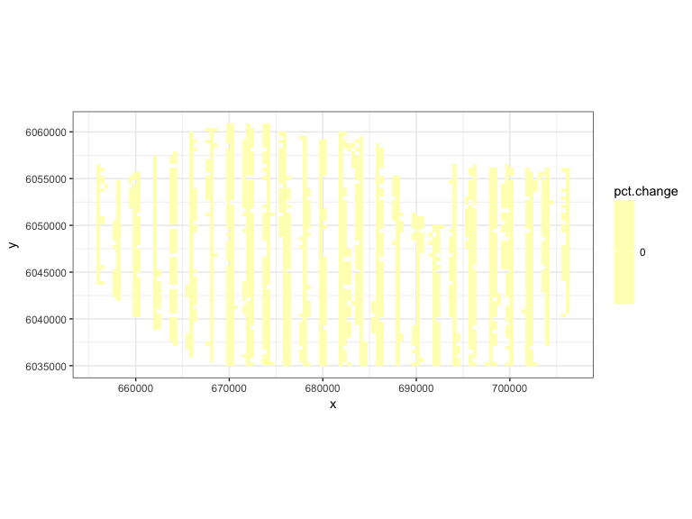

```r
ggplot( NULL ) + geom_raster( data = rdf1 , aes( x , y , fill = pct.change ) ) +
  scale_fill_gradientn(colours=mypalette,values=c(0,1), space = "Lab",
                       na.value = "grey50", guide = "colourbar") +
  theme_bw() + coord_equal()
```

3. We can generate noisy data, based on the assumed model (‘bestModel’) and add any umodelled patterns to give us realistic data.

```r
nsim=500

# add noise
newdata.ny.imp<-generateNoise(nsim, impdata.ny$truth, family='poisson',
                               d=summary(bestModel)$dispersion)

# add correlation
newdatcor.ny.imp<-generateIC(data = impdata.ny, corrs = rbind(corrs,corrs),
                            panels = 'panels', newdata = newdata.ny.imp, nsim = nsim,
                              dots = FALSE)
```

4. We must then update the model to use the new data (`newdatcor.ny.imp`), the `eventphase` term and the panel structure for the new data (twice as many panels).

```r
nysim_glm<-update(bestModel, newdata.ny.imp[,1]~. + eventphase, data=impdata.ny)
nysim_glm$panels<-impdata.ny$panels
```

## Update empirical distribution and prediction grid

5. To ensure we have a reference distribution to run the Empirical Runs Test in each case, we use the independent data.
- be sure that you use the independent data to generate the distribution!

```r
empdistpower.ny<-getEmpDistribution(n.sim = nsim, simData=newdata.ny.imp,
                                  model = nysim_glm, data = impdata.ny, plot=FALSE,
                                  returnDist = TRUE, dots=FALSE)
```

6. Create a suitable prediction grid.
- We must make a prediction grid that allows prediction for pre and post event
- We must also choose a year/month combination
  - Here I have chosen a combination baesd on the output from the partial plots of the model.
  - This year/month combination has a high abundance, but not too much uncertainty.
- Additionally if an offset is present in the model, when setting up the prediction grid the area of each grid cell should be provided so that an accurate estimate of the abundance can be made at the outputs stage.

```r
predictdata<-rbind(data.frame(nysted.predgrid[,2:8], yearmonth='2001/2',
                              area=nysted.predgrid$area, eventphase=0),
                   data.frame(nysted.predgrid[,2:8], yearmonth='2001/2',
                              area=nysted.predgrid$area, eventphase=1))
```

## Power Analysis

7. Now we are ready to run the power analysis function using multiple cores, if possible (nCores=2 here) and it’s best to save the output for further scrutiny.
- I suggest that initially you try some low number of simulations to see how long it takes on your machine. If you can, try using two cores.

```r
nsim=50
```

```r
nysted.power.oc<-powerSimPll(newdatcor.ny.imp, nysim_glm, empdistpower.ny, nsim=nsim,
                             powercoefid=length(coef(nysim_glm)), predictionGrid=predictdata,
                             g2k=NULL, splineParams=NULL, n.boot=100, nCores = 2)
```

```r
save(nysted.power.oc, file='data/powerout.nystedslim.oc.RData', compress = 'bzip2')
```

```r
nsim=100
nysted.power.oc.null<-pval.coverage.null(newdat.ind = newdata.ny.imp,
                                          newdat.corr = newdatcor.ny.imp, model = nysim_glm,
                                          nsim = nsim,  powercoefid = length(coef(nysim_glm)))
```

```r
save(nysted.power.oc.null, file='data/null.output.nystedslim.oc.RData', compress = 'bzip2')
```

## Power Outputs:

1. Summary:

```r
summary(nysted.power.oc, nysted.power.oc.null, truebeta=log(truebeta))
```

```
 ++++ Summary of Power Analysis Output ++++

Number of power simulations =  50
Number of no change simulations =  50

Power to select 'change' term (eventphase term):

    Under Change (true parameter = -0.2231436) = 70%
    Under no change (true parameter = 0) = 6%

Coverage for 'change' coefficient:

    Under model = 94%
    Under no change = 94%

Overall Abundance Summary with 95% Confidence Intervals:

       Abundance LowerCI UpperCI
Before    665944  546539  795944
After     530319  427783  619057

Note: These calculations assume the correct area has been given for each prediction grid cell.
```

2. Burden of proof plot:

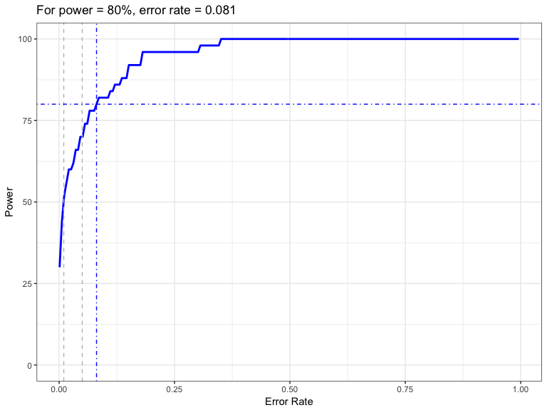

```r
powerPlot(nysted.power.oc)
```

3. Assessment of predictions/differences
- remember if you wish to plot these yourself, you can store the output using `returndata=TRUE`.

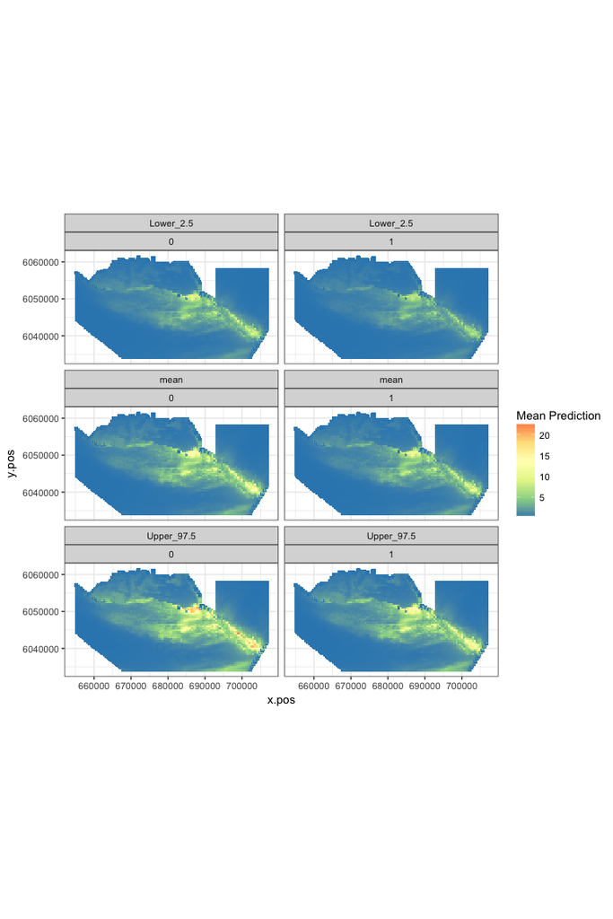

Figure showing the mean (middle), lower 2.5% (top) and upper 97.5% (bottom) of predicted animal counts before (left) and after (right) the event.

```r
plot.preds(nysted.power.oc, cellsize=c(1000,1000))
```

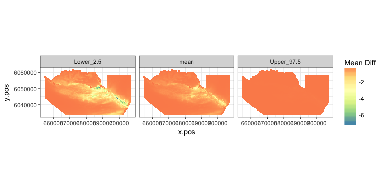

Figure showing the mean (middle), lower 2.5% (left) and upper 97.5% (right) of estimated differences between before and after the event. (difference = post - pre)

```r
plot.diffs(nysted.power.oc, cellsize=c(1000, 1000))
```

4. Spatially Explicit Differences

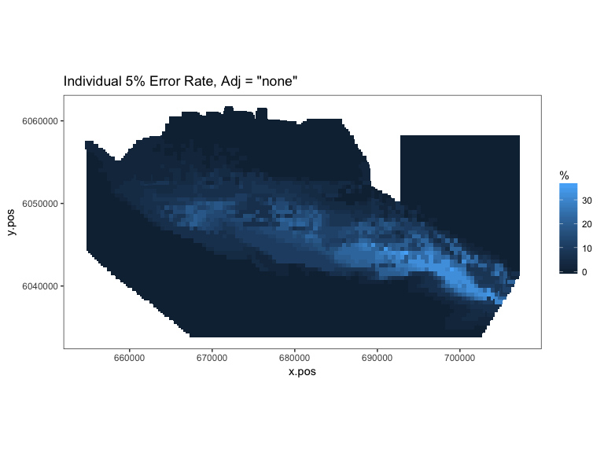

Figure showing, for every grid cell, the proportion of simulations that showed a significant difference.

```r
plot.sigdiff(nysted.power.oc,
             coordinates = predictdata[predictdata$eventphase==0,c('x.pos', 'y.pos')],
             tailed='two', error.rate = 0.05, gridcell.dim = c(1000,1000))
```

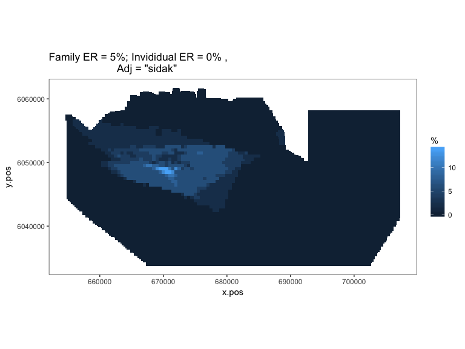

Figure showing, for every grid cell, the proportion of simulations that showed a significant difference (with Sidak adjustment for family error rate of 0.05).

```r
plot.sigdiff(nysted.power.oc,
             coordinates = predictdata[predictdata$eventphase==0,c('x.pos', 'y.pos')],
             tailed='two', error.rate = 0.05, adjustment='sidak', gridcell.dim = c(1000,1000))
```

Try using the bonferroni adjustment and see if there are any differences in outputs.

# Inducing a redistribution: a 50% decline in the wind farm footprint and a re-distribution to the surrounding region

In this case, we wish to depress animal numbers inside a polygon (which represents the footprint of the wind farm in this case). Here we choose to have a 50% decline of animal counts within the footprint after the event has occurred and an inflation of numbers elsewhere to compensate.

1. First we are going to add the buffer to the windfarm footprint. I have chosen a 2 km buffer.
- Handily, there is a function in the `raster` package that computes this, although it requires the polygon to be of the class `SpatialPolygons`, which makes things a bit messy.

```r
require(raster)
bndwf_buf<-data.frame(buffer(SpatialPolygons(list(
                Polygons(list(Polygon(nysted.bndwf)),ID = 1))),width=2000)@
                polygons[[1]]@Polygons[[1]]@coords)
names(bndwf_buf)<-c('x.pos', 'y.pos')
detach(package:raster)
```

## Data Generation:

2. Now we can generate our redistribution data:
- Note that we have the bestModel from earlier so we can use it again.

```r
truebeta<-0.5
impdata.nyre<-genChangeData(truebeta*100, model = bestModel, data = nysted,
                            panels = "panelid", eventsite.bnd = bndwf_buf)
```

```r
impdata.nyre$redistid<-paste(impdata.nyre$eventphase, impdata.nyre$noneventcells)
t<-group_by(impdata.nyre, redistid)%>%
  summarise(sum=sum(truth), mean=mean(truth), n=n())
t
```

```
# A tibble: 4 × 4
  redistid       sum     mean     n
     <chr>     <dbl>    <dbl> <int>
1      0 0  2060.082 4.650297   443
2      0 1 19474.918 3.459747  5629
3      1 0  1030.041 2.325149   443
4      1 1 20504.959 3.642736  5629
```

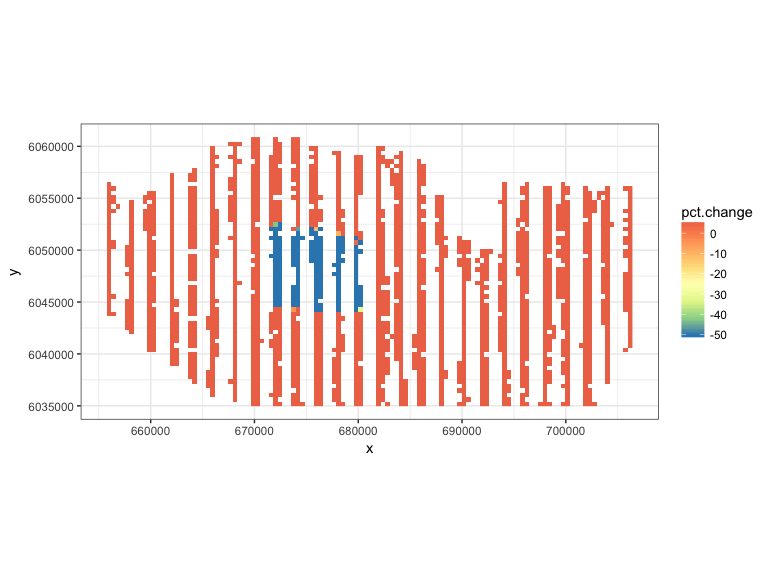

```r
rdf1<-make.raster(ncell.y = 60,
                  xyzdata =impdata.nyre[impdata.nyre$eventphase==0,c('x.pos', 'y.pos', 'truth')],
                  z.name = 'Mean.count')

rdf2<-make.raster(ncell.y = 60,
                  xyzdata = impdata.nyre[impdata.nyre$eventphase==1,c('x.pos', 'y.pos', 'truth')],
                  z.name = 'Mean.count')

rdf<-rbind(data.frame(rdf1,evph=0) , data.frame(rdf2, evph=1))

pct.change<-((rdf$Mean.count[rdf$evph==1] - rdf$Mean.count[rdf$evph==0])/
               rdf$Mean.count[rdf$evph==0])*100

ggplot( NULL ) + geom_raster( data = rdf1 , aes( x , y , fill = pct.change ) ) +

  scale_fill_gradientn(colours=mypalette,
                       values = c(0,0.1, 0.2, 0.3, 0.4, 0.5, 0.6,0.8,1, 10),
                       space = "Lab", na.value = "grey50",
                       guide = "colourbar") +
  theme_bw() + coord_equal()
```

3. Make noisy/correlated data:

```r
nsim=500
newdata.ny.impre<-generateNoise(nsim, impdata.nyre$truth, family='poisson',
                               d=summary(bestModel)$dispersion)
newdatcor.ny.impre<-generateIC(data = impdata.nyre, corrs = rbind(corrs,corrs),
                              panels = 'panels', newdata = newdata.ny.imp,
                              nsim = nsim, dots = FALSE)
```